# Protagonismo Programático e Migração Partidária - uma análise da 56ª Legislatura

2024-09-06

## Objeto

### Tema Central

O objeto deste trabalho é a migração partidária, compreendida como a troca de partido político efetuada por parlamentar durante o exercício do mandato eletivo.

## Questões de Pesquisa

- Existe uma relação significativa entre o protagonismo programático e a migração partidária?
- Qual a diferença no protagonismo programático entre deputados que migraram e os que não migraram?

## Hipótese

- H1: Parlamentares com altos níveis de protagonismo programático tem menos chances de migrar de partido.

## Objetivos

1. Analisar a relação entre o protagonismo programático e os padrões de migração partidária na Câmara dos Deputados;
2. Criar índice de protagonismo programático a partir da Análise de Componentes Principais (PCA);
3. Empreender testes estatísticos para entender a relação entre as duas variáveis (regressão logística e diferença entre médias).

## Contexto

### Justificativa

- A migração partidária é fenômeno capaz de alterar a correlação de forças entre os partidos dentro do Parlamento. Compreender os tipos de incentivos que ensejam a decisão de mudar de partido pode contribuir à literatura sobre Partidos Políticos e Estudos Legislativos ao sopesar como dinâmicas próprias da atuação legislativa e dos papéis desempenhados pelos legisladores podem influenciar a decisão pela migração partidária.

## Método

### Coleta dos Dados

- Os dados relacionados à construção do índice de protagonismo programático foram coletados da plataforma de Dados Abertos da Câmara dos Deputados;
- Os dados relacionados à migração partidária foram acessados via pedido de acesso à informação e fornecidos pela Câmara dos Deputados em formato excel.

### Manipulação dos dados

- Os dados que constituem as variáveis “audiência pública”, “autoria de PL e PLP” e “coordenação de frente parlamentar” foram agregados em números absolutos para cada parlamentar dentro da 56ª legislatura. A partir dos valores atribuídos a cada parlamentar, procedeu-se à Análise de Componentes Principais para elaboração do índice de protagonismo programático. Os gráficos a seguir representam a distribuição das variáveis a partir do z-valor.

### Distribuição dos deputados em relação à variável “audiencias_publicas”

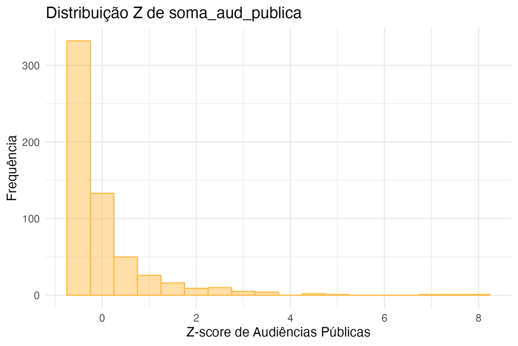

### Distribuição dos deputados em relação à variável “autoria de PL e PLP”

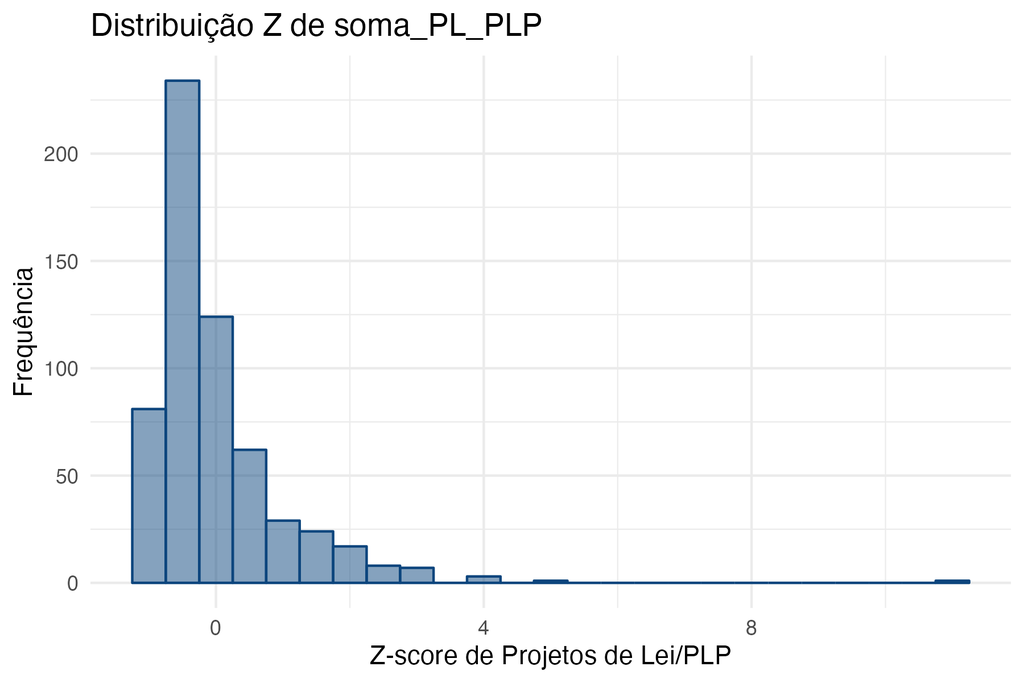

### Distribuição dos deputados em relação à variável “coordenação de frente parlamentar”

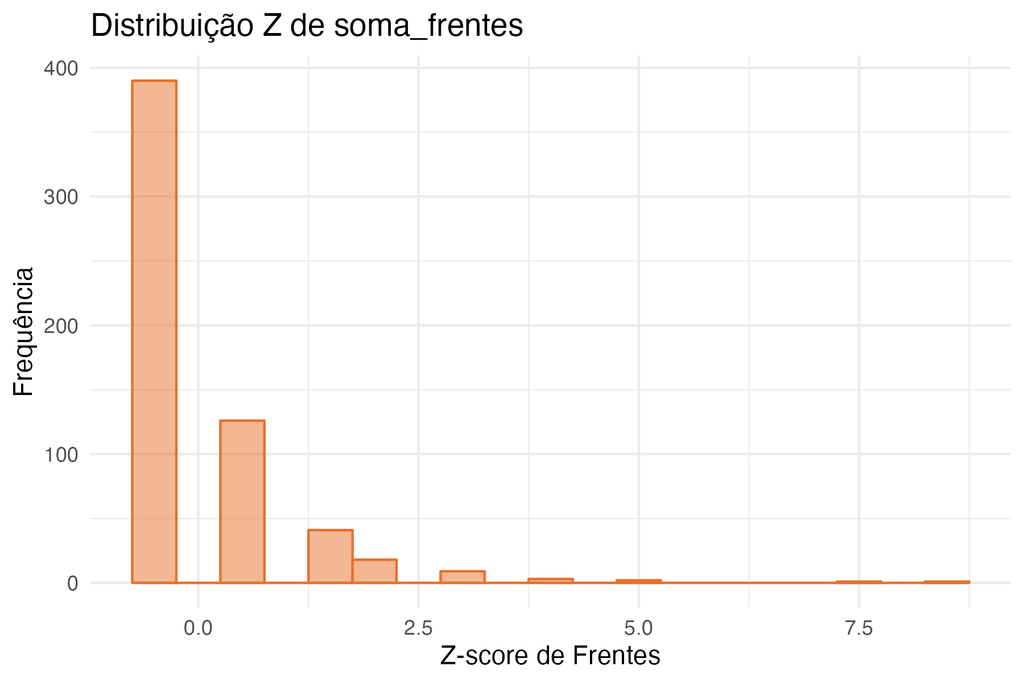

## Análise de Componentes Principais

- Para criar o índice de protagonismo, utilizou-se a Análise de Componentes Principais para reduzir o número de variáveis a um único índice representativo do conjunto de variáveis. O gráfico a seguir apresenta a variância explicada pelo PCA das três variáveis que compõem o índice de protagonismo programático.

### Variância explicada pelas variáveis utilizadas no PCA

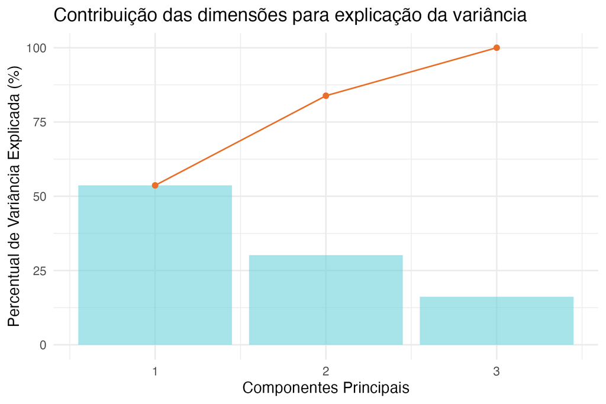

## Criação do índice a partir do PCA

- Uma vez que o “eigenvalue” foi calculado para cada uma das observações, foi realizada a média ponderada do valor atribuído a cada deputado, considerando os distintos pesos resultantes do PCA.
- Em uma segunda etapa, o valor resultante da média ponderada foi normalizado para que ficasse entre 0 e 1, facilitando a análise e a comparação dos dados entre os parlamentares.

### Distribuição dos parlamentares em relação ao índice de protagonismo programático

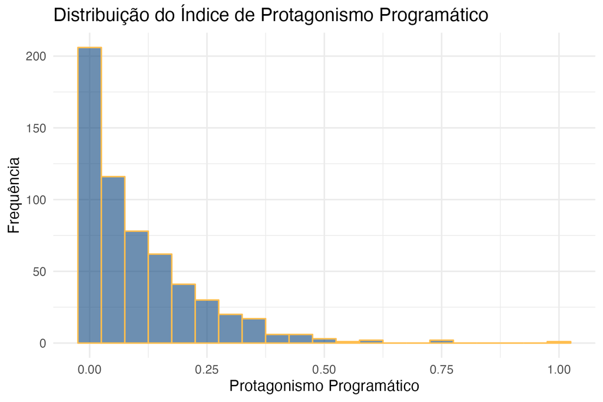

## Codificando deputados migrantes e não migrantes

- Para entender os efeitos do protagonismo na migraçao partidária, os deputados que trocaram de partido na 56ª legislatura foram codificados como 1 e os não migrantes como 0.
- Considerando que a variável dependente (migração) é uma dummy, a regressão logística torna-se o modelo mais adequado para o teste da hipótese (níveis mais altos de protagonismo posicional diminuem a probabilidade de migração partidária).

## Resultado da regressão

Resultados da Regressão Logística

|  | Estimate | Std. Error | z value | Pr(>\|z\|) | significancia |
| --- | --- | --- | --- | --- | --- |
| (Intercept) | -0.7335019 | 0.1179674 | -6.217836 | 0.00000 | *** |
| protagonismo_programatico | -1.2228599 | 0.7803301 | -1.567106 | 0.11709 |  |

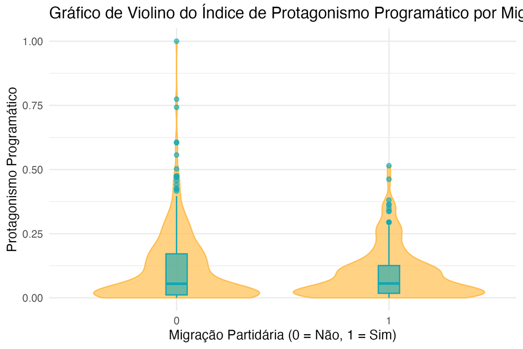

## Próximos passos

- Testar o índice de protagonismo programático e sua relação com a migração partidária para outras legislaturas;
- Construir e testar o índice de protagonismo posicional, com o fito de testar o impacto da ocupação de posições chave dentro da legislatura na migração partidária.